```python
import numpy as np
import matplotlib.pyplot as plt
import scipy.stats as sts
import statsmodels.api as sm

import statsmodels.stats.proportion as st
from random import randint
from matplotlib.pyplot import cm
import random
%matplotlib inline
```

# Гречишкин Денис ПМ-31

# Лабораторная работа №5

## Часть 4.4

## Пример 1

```python
x = np.array([4.740, 4.747, 4.749, 4.758, 4.761, 4.764, 4.764, 4.764, 4.765, 4.767, 4.768,
4.769, 4.769, 4.771, 4.771, 4.772, 4.772, 4.772, 4.774, 4.775, 4.775, 4.776,
4.777, 4.777, 4.778, 4.779, 4.779, 4.779, 4.781, 4.781, 4.782, 4.783, 4.783,
4.785, 4.785, 4.785, 4.788, 4.788, 4.789, 4.789, 4.790, 4.790, 4.790, 4.791,
4.791, 4.791, 4.792, 4.792, 4.795, 4.797, 4.799, 4.799, 4.801, 4.805, 4.806,
4.808, 4.809, 4.810])
n = x.size
beta = 0.9
m_v = np.mean(x)
s2 = np.var(x, ddof = 1)
t = sts.t(n - 1).ppf((1 + beta)/2)
m_min = m_v - t * np.sqrt(s2) / np.sqrt(n)
m_max = m_v + t * np.sqrt(s2) / np.sqrt(n)
print('границы доверительного интервала для m (получены по формулам)', m_min, m_max)
m_interval = sm.stats.zconfint(x, alpha = 1 - beta)
print('границы доверительного интервала для m (использовались функции)', m_interval)
```

```
границы доверительного интервала для m (получены по формулам) 4.777453048066084 4.7841676415890895
границы доверительного интервала для m (использовались функции) (4.777507613759897, 4.784113075895276)
```

```python
chi2_1 = sts.chi2(n - 1).ppf((1 + beta)/2)
chi2_2 = sts.chi2(n - 1).ppf((1 - beta)/2)
Dx_min= (n - 1)*s2/chi2_1
Dx_max = (n - 1)*s2/chi2_2
print('границы доверительного интервала для D(получены по формулам):', Dx_min, Dx_max)
```

```
границы доверительного интервала для D(получены по формулам): 0.00017625301658381803 0.0003279273701255804
```

```python
delta = 0.005
std_v = np.std(x, ddof = 1)
a = delta * np.sqrt(n) / std_v
p = sts.t(n - 1).cdf(a) - sts.t(n - 1).cdf(-a)
print('веоятность не превышения ошибки значения delta:', p)
```

```
веоятность не превышения ошибки значения delta: 0.9842912775152693
```

пример 2

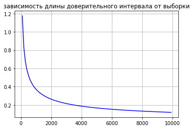

```python
beta = 0.95
sigma = 3
nn = np.arange(100, 10000, 100)
u = sts.norm(0, 1).ppf((1 + beta) / 2)
l = 2 * u * sigma / np.sqrt(nn)
plt.plot(nn, l, color = 'b')
plt.grid(True)
plt.title('зависимость длины доверительного интервала от выборки')
```

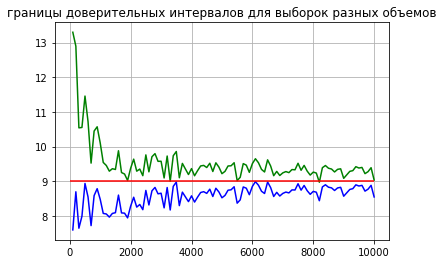

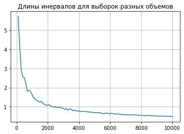

```python
beta = 0.95
m = 10
sigma = 3
n_min = 100
n_max = 10000
Dx_interval_min = []
Dx_interval_max = []
for n in np.arange(n_min, n_max + 1, 100):
    x_n = np.random.normal(loc = m, scale = sigma, size = n)
    s2 = np.var(x_n, ddof = 1)
    Dx_min = (n - 1) * s2 / sts.chi2(n - 1).ppf((1 + beta) / 2)
    Dx_max = (n - 1) * s2 / sts.chi2(n - 1).ppf((1 - beta) / 2)
    Dx_interval_min = np.append(Dx_interval_min, Dx_min)
    Dx_interval_max = np.append(Dx_interval_max, Dx_max)
plt.plot(np.arange(n_min, n_max + 1, 100), Dx_interval_min, color = 'b')
plt.plot(np.arange(n_min, n_max + 1, 100), Dx_interval_max, color = 'g')
plt.hlines(sigma ** 2, 0, n_max, color = 'r')
plt.title('границы доверительных интервалов для выборок разных объемов')
plt.grid(True)
plt.figure()
plt.plot(np.arange(n_min, n_max + 1, 100), Dx_interval_max - Dx_interval_min)
plt.title('Длины инервалов для выборок разных объемов')
plt.grid(True)
```

## Часть 5.5: Задания для самостоятельного выполнения

## Задание 1:

Проведите вычислительные эксперименты для иллюстрации понятия доверительного интервала. Сгенерируйте выборку фиксированного объема $n \ge 100$ из генеральной совокупности, имеющей нормальное распределение с конкретными параметрами $m, \sigma$ (значение параметров $m, \sigma$, и объем выборки выберите самостоятельно). По выборке постройте доверительный интервал для математического ожидания при неизвестной дисперсии (доверительную вероятность примите равной 0,95). Повторите расчеты еще для 49 выборок. 1) Какая часть из полученных интервалов накроет параметр m? Сопоставьте результаты с доверительной вероятностью и прокомментируйте. 2) Визуализируйте результаты, представив найденные доверительные интервалы параллельными вертикальными отрезками (интервалы занумеруйте, номера отложите по оси абсцисс). Повторите эксперимент, увеличив число выборок. Как согласуются полученные результаты с понятием доверительного интервала?

## Решение:

сгенерируем 49 выборок объема 1000 по нормальному распределению с параметрами $m = 3, \sigma = 5$, найдем с помощью встроенной функции доверительный интервал для мат ожидания при неизвестной дисперсии и для каждой выборки построим в виде вертикальных линий.

```
Доверительный интервал для первой выборки: (2.5013915094437804, 3.142282096962828)

левая граница довер. интервала 	 правая граница довер. интервала 	 попадение/непопадание мат ожидания в интервал
	 2.430276506352323 	 	 3.0465514479744025 	 	 	 +
	 2.72201565917873 	 	 3.334658471911335 	 	 	 +
	 2.8524656180800076 	 	 3.4686657576455464 	 	 	 +
	 2.669148244448502 	 	 3.270035653069791 	 	 	 +
	 2.624003605540878 	 	 3.233453893477898 	 	 	 +
	 2.622761359720256 	 	 3.2359435763566093 	 	 	 +
	 2.7684890431020044 	 	 3.3965427072316805 	 	 	 +
	 2.871359141734089 	 	 3.5032882213682854 	 	 	 +
	 2.51884471024155 	 	 3.133890313800254 	 	 	 +
	 2.7297748860885003 	 	 3.359146751996236 	 	 	 +
	 2.8372187005321416 	 	 3.4300167378041557 	 	 	 +
	 2.6749452064744133 	 	 3.3082318361795546 	 	 	 +
	 2.8447844701667657 	 	 3.4444658989410524 	 	 	 +
	 2.6970614361680076 	 	 3.3322401465310283 	 	 	 +
	 2.672217527812932 	 	 3.295540683883849 	 	 	 +
	 2.7180927848985 	 	 3.3363986901478904 	 	 	 +
	 2.8418350948892823 	 	 3.4919151701463282 	 	 	 +
	 2.5995097601623383 	 	 3.200366635432261 	 	 	 +
	 2.809557272159843 	 	 3.42648551368457 	 	 	 +
	 2.8100781545592386 	 	 3.4128430985097036 	 	 	 +
	 2.594405517855478 	 	 3.2159323360399923 	 	 	 +
	 2.7559236644660263 	 	 3.3479268013328083 	 	 	 +
	 2.488378345438388 	 	 3.113635105448717 	 	 	 +
	 2.661717050110049 	 	 3.274170102551955 	 	 	 +
	 2.7136687534563455 	 	 3.318525313692997 	 	 	 +
	 2.732681318904355 	 	 3.3561681134450545 	 	 	 +
	 2.793957435308387 	 	 3.41147746851671 	 	 	 +
	 2.610466867681685 	 	 3.226354963106775 	 	 	 +
	 2.7529563131439856 	 	 3.359329776514209 	 	 	 +
	 2.555469782614756 	 	 3.192730259098329 	 	 	 +
	 2.600367520965235 	 	 3.226384239612809 	 	 	 +
	 2.394540951728055 	 	 2.997688298398572 	 	 	 -
	 2.4662154345198917 	 	 3.104863624657719 	 	 	 +
	 2.5449395841635436 	 	 3.1633882816342993 	 	 	 +
	 2.8503390309765426 	 	 3.4512283906216266 	 	 	 +
	 2.8989964164619195 	 	 3.5378080022458542 	 	 	 +
	 2.570142466302617 	 	 3.193267728480943 	 	 	 +
	 2.6105955697007013 	 	 3.2329052624626784 	 	 	 +
	 2.3339502335623297 	 	 2.9665794099338894 	 	 	 -
	 2.695139385985106 	 	 3.3270543475121666 	 	 	 +
	 2.6747447568718465 	 	 3.2987626553776357 	 	 	 +
	 2.804411819220539 	 	 3.405389090027397 	 	 	 +
	 2.7048609327242947 	 	 3.3374280575924504 	 	 	 +
	 2.8133373466505915 	 	 3.408487262349526 	 	 	 +
	 2.829518477768153 	 	 3.4767205797697627 	 	 	 +
	 2.6171195974803902 	 	 3.2370155461897143 	 	 	 +
	 2.6200190016141454 	 	 3.2514268349252893 	 	 	 +
	 2.538169763558707 	 	 3.159964094520798 	 	 	 +
	 2.9132623660427432 	 	 3.534629285518326 	 	 	 +
частота попадания мат ожидания в доверительный интервал на основе 49 выборок 0.9591836734693877
```

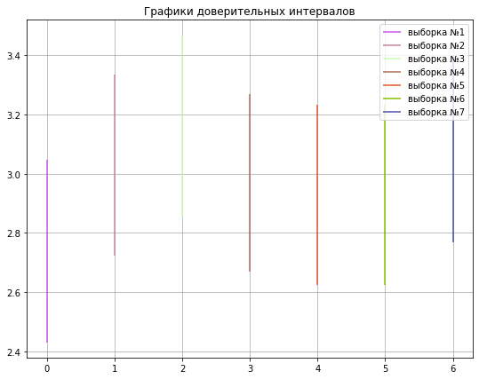

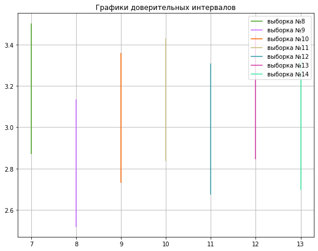

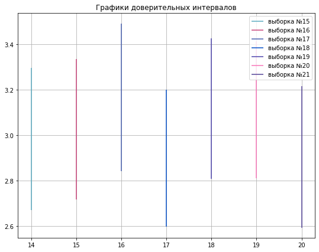

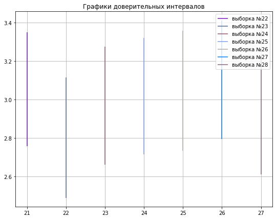

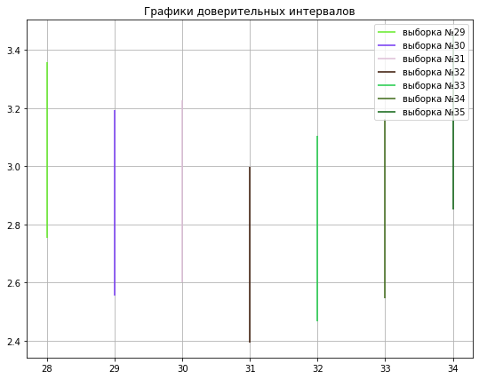

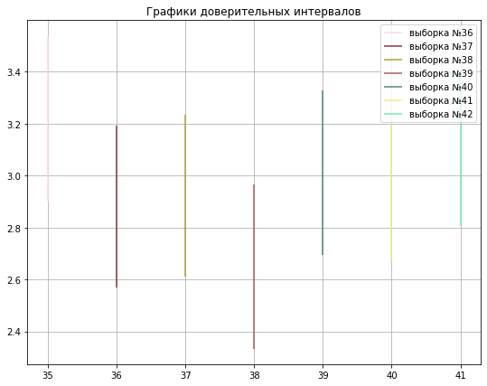

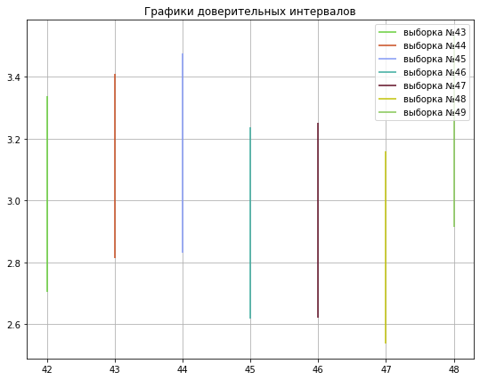

```python
n = 1000
N = 49
m = 3
sigma = 5
beta = 0.95
selection0 = np.random.normal(m, sigma, n)
interv0 = sm.stats.zconfint(selection0, alpha = 1 - beta, alternative = "two-sided")
print('Доверительный интервал для первой выборки:', interv0, '\n')
print('левая граница довер. интервала \t правая граница довер. интервала \t попадение/непопадание мат ожидания в интервал')

count = 0
graphics = 0
colors = []
for i in range(N):
    colors.append('#%06X' % randint(0, 0xFFFFFF))#формируем массив из 49 цветов
plt.figure(figsize = (9, 7))

c = 0
for i in range(N):
    selection = np.random.normal(m, sigma, n)
    interv = sm.stats.zconfint(selection, alpha = 1 - beta, alternative = "two-sided")

    if ((graphics >= 7) and (graphics % 7 == 0)):
        plt.figure(figsize = (9, 7))

    #len_interv = interv[1] - interv[0]
    #l = np.arange(-len_interv/2, len_interv/2, 1000)
    plt.vlines(i, ymin = interv[0], ymax = interv[1], color = colors[i], label = f'выборка №{i+1}')
    graphics += 1
    plt.grid(True)
    plt.legend()
    plt.title('Графики доверительных интервалов')

    if ((m > interv[0]) and (m < interv[1])):
        print('\t', interv[0], '\t \t', interv[1], '\t \t \t', '+')
        count += 1
    else:
        print('\t', interv[0], '\t \t', interv[1], '\t \t \t', '-')



print(f'частота попадания мат ожидания в доверительный интервал на основе {N} выборок',  count/N)
```

теперь повторим тот-же эксперимент со 105-ю выборками

```
Доверительный интервал для первой выборки: (2.7564869449646614, 3.3735900579958833)

левая граница довер. интервала 	 правая граница довер. интервала 	 попадение/непопадание мат ожидания в интервал
	 2.7350002081052374 	 	 3.3564264498757295 	 	 	 +
	 2.4944347948997945 	 	 3.1398440508396166 	 	 	 +
	 2.635199106562703 	 	 3.2666045036825166 	 	 	 +
	 2.823467565538296 	 	 3.44274924972866 	 	 	 +
	 2.624132003354921 	 	 3.2544172057956047 	 	 	 +
	 2.540058272031536 	 	 3.1434232022957946 	 	 	 +
	 2.746362758950295 	 	 3.3760725214971057 	 	 	 +
	 2.4027340257537664 	 	 3.038160028485994 	 	 	 +
	 2.3982475927821167 	 	 3.048622901308755 	 	 	 +
	 2.8645715110386014 	 	 3.491035110348279 	 	 	 +
	 2.724611394656779 	 	 3.337683669278301 	 	 	 +
	 2.6140672451575946 	 	 3.2402383527374634 	 	 	 +
	 2.7380107799172166 	 	 3.359931339801427 	 	 	 +
	 2.8407552105231115 	 	 3.4537248817551864 	 	 	 +
	 2.621016591700315 	 	 3.250174333316997 	 	 	 +
	 2.6263932408130395 	 	 3.2707328493995873 	 	 	 +
	 2.846754772787048 	 	 3.4665742854999757 	 	 	 +
	 2.5863131975674696 	 	 3.214097057082526 	 	 	 +
	 2.779122471950365 	 	 3.385109422168382 	 	 	 +
	 2.8380247567986085 	 	 3.453377276325387 	 	 	 +
	 2.6435322445391827 	 	 3.2553887407567283 	 	 	 +
	 2.739223010133033 	 	 3.3459245293469015 	 	 	 +
	 2.17844503922548 	 	 2.819332625757934 	 	 	 -
	 2.715704331940587 	 	 3.305456923629341 	 	 	 +
	 2.6148563467218096 	 	 3.254680295708677 	 	 	 +
	 2.7477953398736688 	 	 3.356361822092441 	 	 	 +
	 2.5308582190081212 	 	 3.1339636870215672 	 	 	 +
	 2.7668659508585107 	 	 3.407337213283466 	 	 	 +
	 2.651355983440103 	 	 3.2741624338678315 	 	 	 +
	 2.711099595038085 	 	 3.3340213553739306 	 	 	 +
	 2.4990496848457253 	 	 3.1503778946830012 	 	 	 +
	 2.77943875064231 	 	 3.398654245077827 	 	 	 +
	 2.739287512383491 	 	 3.3762571150199694 	 	 	 +
	 2.6753674320632217 	 	 3.286053931721718 	 	 	 +
	 2.558392855180505 	 	 3.1791854673088653 	 	 	 +
	 2.621019873201673 	 	 3.2465435830987657 	 	 	 +
	 2.4824491616094995 	 	 3.1239092031928 	 	 	 +
```

[output cut: 54 more lines]

```
	 2.931830368894376 	 	 3.5722929899353097 	 	 	 +
	 2.9288001257115015 	 	 3.547187532717639 	 	 	 +
	 2.5978877564963896 	 	 3.204794971060823 	 	 	 +
	 2.7187279195154788 	 	 3.3268230579532587 	 	 	 +
	 2.51346775573541 	 	 3.1206209287101605 	 	 	 +
	 2.7594859401914658 	 	 3.3839809356895563 	 	 	 +
	 2.645762917795908 	 	 3.2515969202436024 	 	 	 +
	 2.4822371156887826 	 	 3.1116192547328394 	 	 	 +
	 2.569406586777811 	 	 3.2018697185388305 	 	 	 +
	 2.5448847560596937 	 	 3.166933042982768 	 	 	 +
	 2.65334204236169 	 	 3.290864019722114 	 	 	 +
	 2.5056454824564622 	 	 3.101153910799485 	 	 	 +
	 2.786733376026328 	 	 3.3972036570436313 	 	 	 +
	 2.738082049641416 	 	 3.3472160355575915 	 	 	 +
частота попадания мат ожидания в доверительный интервал на основе 105 выборок 0.9619047619047619
```

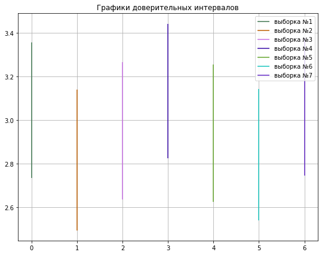

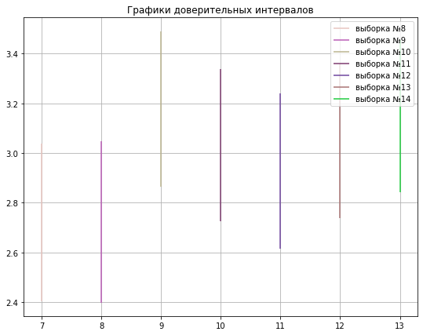

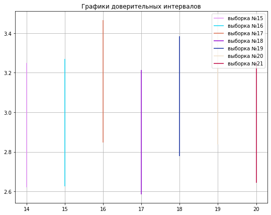

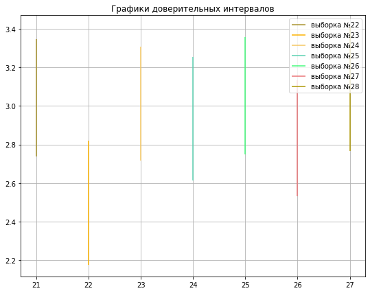

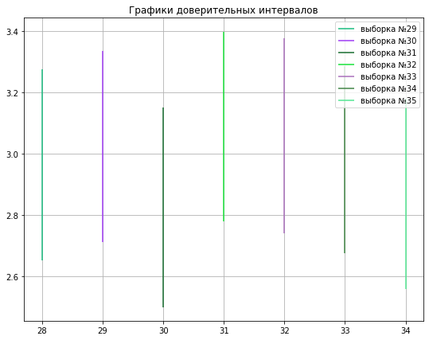

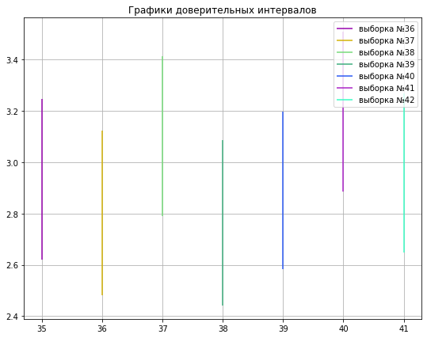

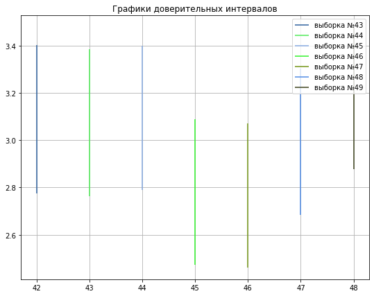

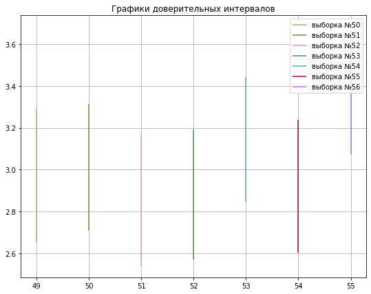

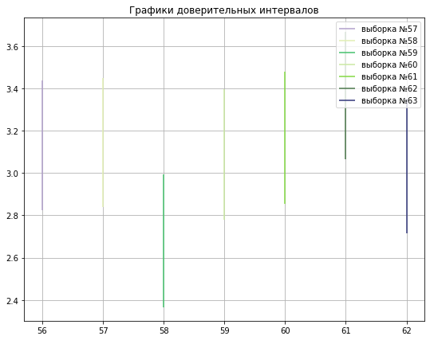

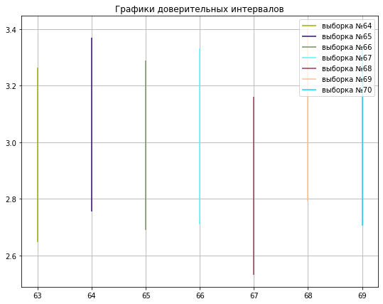

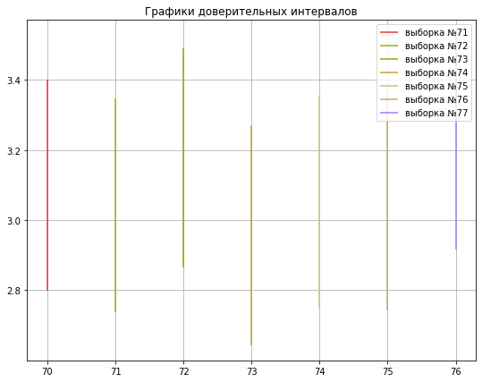

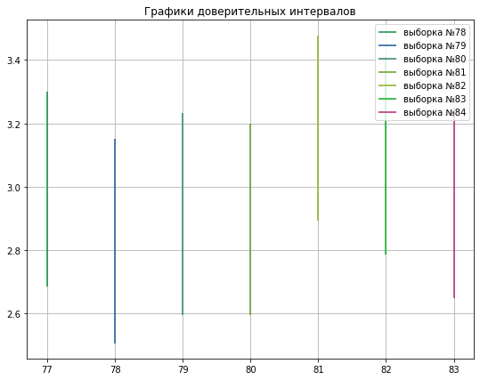

[3 more figures not shown]

```python
n = 1000
N = 105
m = 3
sigma = 5
beta = 0.95
selection0 = np.random.normal(m, sigma, n)
interv0 = sm.stats.zconfint(selection0, alpha = 1 - beta, alternative = "two-sided")
print('Доверительный интервал для первой выборки:', interv0, '\n')
print('левая граница довер. интервала \t правая граница довер. интервала \t попадение/непопадание мат ожидания в интервал')

count = 0
graphics = 0
colors = []
for i in range(N):
    colors.append('#%06X' % randint(0, 0xFFFFFF))#формируем массив из 49 цветов
plt.figure(figsize = (9, 7))

c = 0
for i in range(N):
    selection = np.random.normal(m, sigma, n)
    interv = sm.stats.zconfint(selection, alpha = 1 - beta, alternative = "two-sided")

    if ((graphics >= 7) and (graphics % 7 == 0)):
        plt.figure(figsize = (9, 7))

    plt.vlines(i, ymin = interv[0], ymax = interv[1], color = colors[i], label = f'выборка №{i+1}')
    graphics += 1
    plt.grid(True)
    plt.legend()
    plt.title('Графики доверительных интервалов')

    if ((m > interv[0]) and (m < interv[1])):
        print('\t', interv[0], '\t \t', interv[1], '\t \t \t', '+')
        count += 1
    else:
        print('\t', interv[0], '\t \t', interv[1], '\t \t \t', '-')



print(f'частота попадания мат ожидания в доверительный интервал на основе {N} выборок',  count/N)
```

Экспериментально можно подтвердить что частота интервалов, накрывающих мат ожидание приблизительно равна доверительной вероятности

$\newline$

## Задание 2: Исследуйте экспериментально зависимость длины доверительного интервала от доверительной вероятности. Сгенерируйте выборку объема $n$ из генеральной совокупности, имеющей нормальное

распределение с конкретными параметрами $m, \sigma$ (значение параметров $n, m, \sigma$ выберите самостоятельно). 1) Постройте в одной системе координат графики зависимости левой и правой границ доверительных интервалов для математического ожидания от значения доверительной вероятности $\beta$. Определите диапазон значений $\beta$, при которых доверительный интервал, построенный по сгенерированной выборке, не накрывает истинное значение математического ожидания. 2) Выполните задание п. 1 для дисперсии. Прокомментируйте полученные результаты.

## Решение:

## Пункт 1: зададим параметр $\beta$ с помощью np.linspace и с помощью встроенной функции найдем доверительные интервалы для соответствующих $\beta$ и построим графики правой и левой границ, а также построим линию мат. ожидания

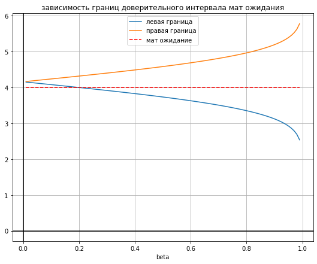

```python
m = 4
sigma = 6
n = 100
selection = np.random.normal(m, sigma, n)
plt.figure(figsize = (9, 7))
beta = np.linspace(0.01, 0.99, 100)
interv = sm.stats.zconfint(selection, alpha = 1 - beta, alternative = "two-sided")
plt.plot(beta, interv[0], label = 'левая граница')
plt.plot(beta, interv[1], label = 'правая граница')
plt.plot(beta, m*beta**0, '--r', label = 'мат ожидание')
plt.grid(True)
plt.axhline(y = 0, color = 'k')
plt.axvline(x = 0, color = 'k')
plt.xlabel('beta')
plt.legend()
plt.title('зависимость границ доверительного интервала мат ожидания')
```

## Пункт 2: проделаем то-же самое для дисперсии

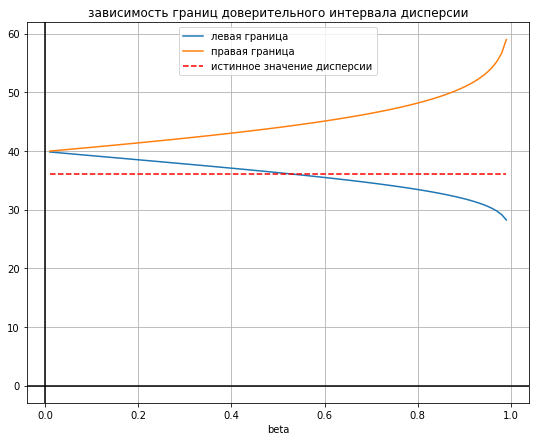

```python
m = 4
sigma = 6
n = 100
#selection = np.random.normal(m, sigma, n)
s2 = np.var(selection, ddof = 1)
plt.figure(figsize = (9, 7))
beta = np.linspace(0.01, 0.99, 100)
chi2_1 = sts.chi2(n - 1).ppf((1 + beta)/2)
chi2_2 = sts.chi2(n - 1).ppf((1 - beta)/2)
Dx_min= (n - 1)*s2/chi2_1
Dx_max = (n - 1)*s2/chi2_2
plt.plot(beta, Dx_min, label = 'левая граница')
plt.plot(beta, Dx_max, label = 'правая граница')
plt.plot(beta, sigma**2*beta**0, '--r', label = 'истинное значение дисперсии')
plt.grid(True)
plt.axhline(y = 0, color = 'k')
plt.axvline(x = 0, color = 'k')
plt.xlabel('beta')
plt.legend()
plt.title('зависимость границ доверительного интервала дисперсии')
```

$\newline$

## Задание 3: Исследуйте вопрос о минимальном объеме выборки, необходимом для достижения заданной точности оценки при проведении экспериментов по схеме Бернулли. $\newline$

При выполнении задания исходите из предположения $X \sim B(n, p), \sqrt{npq} \gg 1$ и используйте приближенный доверительный интервал $$P^* - u_{\frac{1 + \beta}{2}} \cdot \sqrt{\frac{P^*(1 - P^*)}{n}} < p < P^* + u_{\frac{1 + \beta}{2}} \cdot \sqrt{\frac{P^*(1 - P^*)}{n}}$$ 1) Сгенерируйте выборки различных объемов n из генеральной совокупности, имеющей индикаторное распределение с параметром p (значение параметра p выберите самостоятельно). Для каждой выборки найдите доверительный интервал для вероятности события p (доверительную вероятность принять равной 0,95). Результаты визуализируйте, построив график экспериментальной зависимости верхней и нижней границ доверительных интервалов от объема выборки. Экспериментально оцените минимальный объем выборки, позволяющий при заданной доверительной вероятности утверждать, что доля «успехов» в выборке отличается от значения параметра p не более чем на 2%. 2) Теоретически оцените минимальный объем выборки, позволяющий при заданной доверительной вероятности утверждать, что доля «успехов» в выборке отличается от значения параметра p не более чем на 2%. Сравните теоретические и экспериментально полученные результаты. 3) Используя функцию *samplesize_confint_proportion*, оцените минимальный объем выборки, позволяющий при заданной доверительной вероятности утверждать, что доля «успехов» в выборке отличается от значения параметра p не более чем на 2 %. Сравните результаты с результатами п. 1 и п. 2.

## Пункт 1: составим массив размеров от 100 до 10000, через него составим выборки соответствующих размеров, с помощью встроенной функции найдем доверительные интервалы и построим график зависимостей границ интервала

```
размер выборки 	 	 левая граница 	 	 	 правая граница
100 	 	 	 0.4120214023731988 	 	 0.6079785976268013
200 	 	 	 0.4912055433403595 	 	 0.6287944566596406
300 	 	 	 0.5822419544188246 	 	 0.6910913789145088
400 	 	 	 0.574994242092524 	 	 0.6700057579074761
500 	 	 	 0.5794985075065282 	 	 0.6645014924934718
600 	 	 	 0.5455747507893309 	 	 0.624425249210669
700 	 	 	 0.572415367444289 	 	 0.6447274896985681
800 	 	 	 0.5673202241758435 	 	 0.6351797758241564
900 	 	 	 0.5905471365001456 	 	 0.6538973079442989
1000 	 	 	 0.5797695012703539 	 	 0.6402304987296461
1100 	 	 	 0.5848620207367203 	 	 0.642410706536007
1200 	 	 	 0.5613305025411195 	 	 0.6170028307922137
1300 	 	 	 0.588159315581201 	 	 0.6410714536495681
1400 	 	 	 0.5887879475887193 	 	 0.6397834809827093
```

[output cut: 286 more lines]

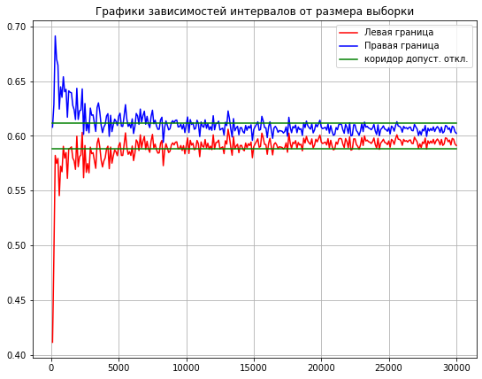

```python
n = 1
sizes = [100*k for k in range(1, 301)]
p_appr = 0.6
beta = 0.95
print('размер выборки \t \t левая граница \t \t \t правая граница')
plt.figure(figsize = (9, 7))
lev_grs = []
pr_grs = []
SELECTS = []
for size in sizes:
    select = np.random.binomial(n, p_appr, size)
    SELECTS.append(select)
    interval = sm.stats.proportion_confint(count = sum(select), nobs = size, alpha = (1 - beta), method='normal')
    print(size, '\t \t \t', interval[0], '\t \t', interval[1])
    lev_grs.append(interval[0])
    pr_grs.append(interval[1])
plt.plot(sizes, lev_grs, '-r', label = 'Левая граница')
plt.plot(sizes, pr_grs, '-b', label = 'Правая граница')


x = np.linspace(sizes[0], sizes[len(sizes) - 1], 1000)
plt.plot(x, 1.02*p_appr*x**0, color = 'g')
plt.plot(x, 0.98*p_appr*x**0, color = 'g', label = 'коридор допуст. откл.')
plt.grid(True)
plt.legend()
plt.title('Графики зависимостей интервалов от размера выборки')
```

Теперь, используя построенные выборки найдем частоту успехов и проверим насколько они отличаются от 2%

```python
n = 1
#sizes = [100*k for k in range(1, 101)]
p_appr = 0.6
beta = 0.95

print('объем выборки \t вер-сть успеха \t частота усп. в выборке \t разница(в %) \t меньше/больше разница чем 2%')
for select in SELECTS:
    #select = np.random.binomial(n, p_appr, size)
    chastota = sum(select)/len(select)
    if (abs((chastota - p_appr)/p_appr) <= 0.02):
        print(len(select), '\t \t \t', p_appr, '\t \t \t', np.round(chastota, 2), '\t \t \t', np.round(abs((chastota - p_appr)/p_appr)*100, 3), '\t \t', '+')
    else:
        print(len(select), '\t \t \t', p_appr, '\t \t \t', np.round(chastota, 2), '\t \t \t', np.round(abs((chastota - p_appr)/p_appr)*100, 3), '\t \t', '-')
```

```
объем выборки 	 вер-сть успеха 	 частота усп. в выборке 	 разница(в %) 	 меньше/больше разница чем 2%
100 	 	 	 0.6 	 	 	 0.51 	 	 	 15.0 	 	 -
200 	 	 	 0.6 	 	 	 0.56 	 	 	 6.667 	 	 -
300 	 	 	 0.6 	 	 	 0.64 	 	 	 6.111 	 	 -
400 	 	 	 0.6 	 	 	 0.62 	 	 	 3.75 	 	 -
500 	 	 	 0.6 	 	 	 0.62 	 	 	 3.667 	 	 -
600 	 	 	 0.6 	 	 	 0.58 	 	 	 2.5 	 	 -
700 	 	 	 0.6 	 	 	 0.61 	 	 	 1.429 	 	 +
800 	 	 	 0.6 	 	 	 0.6 	 	 	 0.208 	 	 +
900 	 	 	 0.6 	 	 	 0.62 	 	 	 3.704 	 	 -
1000 	 	 	 0.6 	 	 	 0.61 	 	 	 1.667 	 	 +
1100 	 	 	 0.6 	 	 	 0.61 	 	 	 2.273 	 	 -
1200 	 	 	 0.6 	 	 	 0.59 	 	 	 1.806 	 	 +
1300 	 	 	 0.6 	 	 	 0.61 	 	 	 2.436 	 	 -
1400 	 	 	 0.6 	 	 	 0.61 	 	 	 2.381 	 	 -
```

[output cut: 286 more lines]

Из графика и таблицы видно что при размере выборки больше или равном 10000 почти все значения попадают в коридор допустимых

## Пункт 2: Для теоретической оценки воспользуемся следующи неравенством:

$$|P - P^*| < u_{\frac{1 + \beta}{2}} \cdot \sqrt{\frac{pq}{n}}$$

```python
n_min = ((sts.norm(0, 1).ppf((beta + 1)/2))**2*(1 - p_appr))/(0.0004*p_appr)
print('n_min:', n_min)
```

```
n_min: 6402.431367823543
```

## Пункт 3:

найдем минимальный объем выборки с помощью функции samplesize_confint_proportion

```python
n = 1
p_appr = 0.6
beta = 0.95
#select = np.random.binomial(n, p_appr, size)
chastota = sum(select)/size
rez = st.samplesize_confint_proportion(p_appr, 0.02*p_appr, 1-beta, method = 'normal')
print('минимальный объем выборки:', rez)
```

```
минимальный объем выборки: 6402.431367823542
```

$\newline$

## Задание 4: Экспериментально сопоставьте методы получения интервальных оценок: параметрический (традиционный) и бутстреп. Сгенерируйте 20 выборок фиксированного объема $n \ge 100$ из генеральной совокупности, имеющей нормальное распределение с конкретными параметрами $m, \sigma$ (значение параметров $m, \sigma$ и объем выборки выберите самостоятельно).

1) Для каждой выборки получите интервальные оценки методом бутстреп для математического ожидания и дисперсии (доверительную вероятность примите равной 0,95). Сопоставьте результат с соответствующими доверительными интервалами, полученными традиционным путем. 2) Визуализируйте результаты, представив парами вертикальных отрезков полученные двумя способами интервальные оценки для математического ожидания. Аналогичное построение выполните для интервальных оценок дисперсии. Прокомментируйте результаты.

## Решение:

## Пункт 1:

для того чтобы сократить код, заранее создадим функцию находящую довер. интервалы традиционным путем. создадим 20 выборок по нормальному распределению с параметрами $m = 3, \sigma = 7$. для каждого из массивов найдем оценки мат ожидания и дисперсии методомь бутстрепа с помощью алгоритма из методички и с помощью функции созданной ранее найдем довер. интервалы с помощью функции созданной ранее

```python
def intervals(selection, beta):
    m_interval = sm.stats.zconfint(selection, alpha = 1 - beta)
    s2 = np.var(selection, ddof = 1)
    chi2_1 = sts.chi2(len(selection) - 1).ppf((1 + beta)/2)
    chi2_2 = sts.chi2(len(selection) - 1).ppf((1 - beta)/2)
    Dx_min= (len(selection) - 1)*s2/chi2_1
    Dx_max = (len(selection) - 1)*s2/chi2_2
    return [m_interval[0], m_interval[1], Dx_min, Dx_max]

beta = 0.95
n = 200
size = 500
N = 1000
m = 3
sigma = 7
amount = 20

m_left_butstrep_gr = []
m_right_butstrep_gr = []
disp_left_butstrep_gr = []
disp_right_butstrep_gr = []
m_left_teor_gr = []
m_right_teor_gr = []
disp_left_teor_gr = []
disp_right_teor_gr = []

for k in range(amount):
    arr_ms = []
    arr_ds = []
    Selection = np.random.normal(m, sigma, size)
    #реализуем метод бутстрепа
    for i in range(N):
        sel1 = random.choices(Selection, k = n)
        m_appr = sum(sel1)/n
        d_appr = 0
        for el in sel1:
            d_appr += (el - m_appr)**2
        d_appr /= (n - 1)
        #sigma_appr = np.sqrt(d_appr)
        arr_ms.append(m_appr)
        arr_ds.append(d_appr)

    arr_ms.sort()
    arr_ds.sort()
    m_left_butstrep_gr.append(np.quantile(arr_ms, 0.025))
    m_right_butstrep_gr.append(np.quantile(arr_ms, 0.975))
    disp_left_butstrep_gr.append(np.quantile(arr_ds, 0.025))
    disp_right_butstrep_gr.append(np.quantile(arr_ds, 0.975))

    teor_grs = intervals(Selection, beta)
    m_left_teor_gr.append(teor_grs[0])
    m_right_teor_gr.append(teor_grs[1])
    disp_left_teor_gr.append(teor_grs[2])
    disp_right_teor_gr.append(teor_grs[3])

print('ОЦЕНКИ МАТ ОЖИДАНИЯ:\n')
print('бутстреп: левая граница интервала \t бутстреп: правая граница интервала \t теоретический: левая граница интервала \t теоретический: правая граница интервала')
for k in range(amount):
    print(m_left_butstrep_gr[k], '\t \t \t',  m_right_butstrep_gr[k], '\t \t \t', m_left_teor_gr[k], '\t \t \t \t', m_right_teor_gr[k])

print('\n')
print('ОЦЕНКИ ДИСПЕРСИИ:\n')
print('бутстреп: левая граница интервала \t бутстреп: правая граница интервала \t теоретический: левая граница интервала \t теоретический: правая граница интервала')
for k in range(amount):
    print(disp_left_butstrep_gr[k], '\t \t \t',  disp_right_butstrep_gr[k], '\t \t \t', disp_left_teor_gr[k], '\t \t \t \t', disp_right_teor_gr[k])
```

```
ОЦЕНКИ МАТ ОЖИДАНИЯ:

бутстреп: левая граница интервала 	 бутстреп: правая граница интервала 	 теоретический: левая граница интервала 	 теоретический: правая граница интервала
2.4585364731890245 	 	 	 4.461664536291134 	 	 	 2.818748098725474 	 	 	 	 4.113155055730384
1.6410027797728517 	 	 	 3.4664220769155887 	 	 	 1.9674574443750017 	 	 	 	 3.186910516405009
1.9159871097200971 	 	 	 3.763918625203188 	 	 	 2.229934072702651 	 	 	 	 3.4063880728540745
2.158273297553496 	 	 	 4.085488805125456 	 	 	 2.529575567152644 	 	 	 	 3.7195499451743674
1.8467647737222013 	 	 	 3.779102399549512 	 	 	 2.172936837469143 	 	 	 	 3.4265485750293596
2.446714121612169 	 	 	 4.3391431723675495 	 	 	 2.8025499816977106 	 	 	 	 4.041223403585183
2.2882592199947096 	 	 	 4.2494098751689 	 	 	 2.6762184261645237 	 	 	 	 3.9337110487228015
1.7644989400129307 	 	 	 3.766767657627731 	 	 	 2.0953253312365603 	 	 	 	 3.3585290141695325
1.632046129289022 	 	 	 3.4902434709302983 	 	 	 1.9548128788987826 	 	 	 	 3.1536062000415255
1.8659803021434223 	 	 	 3.904352578588281 	 	 	 2.2217752707821514 	 	 	 	 3.4756904715747794
1.9345676681004154 	 	 	 3.9326953094551764 	 	 	 2.2156365604174635 	 	 	 	 3.5122269296544237
1.9866488273689822 	 	 	 3.909987627309973 	 	 	 2.3336507678154788 	 	 	 	 3.5691259487868723
1.7050579852110073 	 	 	 3.4905531454008143 	 	 	 2.0652298614896556 	 	 	 	 3.2278884389493983
1.610632839835976 	 	 	 3.4968951787783435 	 	 	 1.9404637949597412 	 	 	 	 3.1353717530165808
2.8023309303579453 	 	 	 4.794090048282379 	 	 	 3.1389502103836446 	 	 	 	 4.43929749081693
2.812405517706204 	 	 	 4.686681232616585 	 	 	 3.0996384224089084 	 	 	 	 4.300580894254836
2.409587636058192 	 	 	 4.187779228274451 	 	 	 2.6767939512086882 	 	 	 	 3.8610006132807464
2.126258882430019 	 	 	 4.056473450311621 	 	 	 2.5503635756653766 	 	 	 	 3.719182362267224
1.2865633287296272 	 	 	 3.330261527262145 	 	 	 1.6211109375087656 	 	 	 	 2.9392097567370694
2.003121915051431 	 	 	 3.9600168003607705 	 	 	 2.376162285287488 	 	 	 	 3.610126462092911


ОЦЕНКИ ДИСПЕРСИИ:

бутстреп: левая граница интервала 	 бутстреп: правая граница интервала 	 теоретический: левая граница интервала 	 теоретический: правая граница интервала
44.77216297267952 	 	 	 64.55516533777151 	 	 	 48.340381156336065 	 	 	 	 61.97171139170843
39.309540280999286 	 	 	 57.73017839461378 	 	 	 42.90407841531745 	 	 	 	 55.00244519136939
36.22682221807349 	 	 	 54.31081868588441 	 	 	 39.931745543124926 	 	 	 	 51.191954861971986
38.06850451237464 	 	 	 55.41004115854858 	 	 	 40.85484944728399 	 	 	 	 52.37536151629885
41.55797646851015 	 	 	 61.814450629449006 	 	 	 45.34135483667445 	 	 	 	 58.12700042558799
40.70443960063712 	 	 	 59.76178845192096 	 	 	 44.26719785009535 	 	 	 	 56.74994577336289
42.102907005764955 	 	 	 61.29161401713935 	 	 	 45.62252156610512 	 	 	 	 58.48745234988864
41.96683560533561 	 	 	 62.840168454128374 	 	 	 46.03786339384038 	 	 	 	 59.0199149259298
36.802076630831515 	 	 	 57.33383700867335 	 	 	 41.46264686832144 	 	 	 	 53.15454954626789
41.65492585574308 	 	 	 61.749715642660654 	 	 	 45.36330916123819 	 	 	 	 58.15514557118095
44.81320235717844 	 	 	 64.98208772659758 	 	 	 48.50360030088364 	 	 	 	 62.180956115840644
40.20969153058256 	 	 	 60.1762375699824 	 	 	 44.0388981456213 	 	 	 	 56.457268656260275
36.72423214816223 	 	 	 51.828392048237355 	 	 	 39.00073514928594 	 	 	 	 49.99841219537454
37.84708469218371 	 	 	 56.110960342996684 	 	 	 41.19431642072185 	 	 	 	 52.81055356074864
45.385063189384404 	 	 	 65.15676519905062 	 	 	 48.78508892339425 	 	 	 	 62.541820702693215
38.34382239427 	 	 	 56.448024485523874 	 	 	 41.61144541620546 	 	 	 	 53.3453072615443
37.582059918691236 	 	 	 55.55223729841967 	 	 	 40.459768496809225 	 	 	 	 51.86887310943252
36.75007567618833 	 	 	 52.70319576832163 	 	 	 39.41511158811808 	 	 	 	 50.52963715596763
46.12289406767763 	 	 	 67.28813770652779 	 	 	 50.12614839510809 	 	 	 	 64.26104071197265
40.233006650203166 	 	 	 59.43549725586052 	 	 	 43.93124358795376 	 	 	 	 56.31925697703502
```

## Пункт 2:

[figure not shown]

[figure not shown]

```python
c1 = 0
c2 = 0

plt.figure(figsize = (9, 7))
plt.vlines(0, ymin = m_left_butstrep_gr[0], ymax = m_right_butstrep_gr[0], color = 'y', label = 'метод бустрепа')
plt.vlines(0.5, ymin = m_left_butstrep_gr[0], ymax = m_right_butstrep_gr[0], color = 'r', label = 'теоретический метод')
for i in range(1, amount):
    plt.vlines(i, ymin = m_left_butstrep_gr[i], ymax = m_right_butstrep_gr[i], color = 'y')
    plt.vlines(i + 0.5, ymin = m_left_butstrep_gr[i], ymax = m_right_butstrep_gr[i], color = 'r')
plt.grid(True)
plt.title('Интералы оценок мат ожидания')
plt.legend()

plt.figure(figsize = (9, 7))

plt.vlines(0, ymin = disp_left_butstrep_gr[0], ymax = disp_right_butstrep_gr[0], color = 'g', label = 'метод бустрепа')
plt.vlines(0.5, ymin = disp_left_butstrep_gr[0], ymax = disp_right_butstrep_gr[0], color = 'b', label = 'теоретический метод')

for i in range(1, amount):
    plt.vlines(i, ymin = disp_left_butstrep_gr[i], ymax = disp_right_butstrep_gr[i], color = 'g')
    plt.vlines(i+0.5, ymin = disp_left_butstrep_gr[i], ymax = disp_right_butstrep_gr[i], color = 'b')

plt.grid(True)
plt.title('Интералы оценок дисперсии')
plt.legend()
```